# PS8_JTung

Tung, Joanna

March 5, 2017

```r
#devtools::install_github("bensoltoff/ggdendro")
```

Dr.Soltoff’s plotting code

```r
# hackish function to get line segment coordinates for ggplot
partition.tree.data <- function (tree, label = "yval", add = FALSE, ordvars, ...)
{
  ptXlines <- function(x, v, xrange, xcoord = NULL, ycoord = NULL,
                       tvar, i = 1L) {
    if (v[i] == "<leaf>") {
      y1 <- (xrange[1L] + xrange[3L])/2
      y2 <- (xrange[2L] + xrange[4L])/2
      return(list(xcoord = xcoord, ycoord = c(ycoord, y1,
                                              y2), i = i))
    }
    if (v[i] == tvar[1L]) {
      xcoord <- c(xcoord, x[i], xrange[2L], x[i], xrange[4L])
      xr <- xrange
      xr[3L] <- x[i]
      ll2 <- Recall(x, v, xr, xcoord, ycoord, tvar, i +
                      1L)
      xr <- xrange
      xr[1L] <- x[i]
      return(Recall(x, v, xr, ll2$xcoord, ll2$ycoord, tvar,
                    ll2$i + 1L))
    }
    else if (v[i] == tvar[2L]) {
      xcoord <- c(xcoord, xrange[1L], x[i], xrange[3L],
                  x[i])
      xr <- xrange
      xr[4L] <- x[i]
      ll2 <- Recall(x, v, xr, xcoord, ycoord, tvar, i +
                      1L)
      xr <- xrange
      xr[2L] <- x[i]
      return(Recall(x, v, xr, ll2$xcoord, ll2$ycoord, tvar,
                    ll2$i + 1L))
    }
    else stop("wrong variable numbers in tree.")
  }
  if (inherits(tree, "singlenode"))
    stop("cannot plot singlenode tree")
  if (!inherits(tree, "tree"))
    stop("not legitimate tree")
  frame <- tree$frame
  leaves <- frame$var == "<leaf>"
  var <- unique(as.character(frame$var[!leaves]))
  if (length(var) > 2L || length(var) < 1L)
    stop("tree can only have one or two predictors")
  nlevels <- sapply(attr(tree, "xlevels"), length)
  if (any(nlevels[var] > 0L))
    stop("tree can only have continuous predictors")
  x <- rep(NA, length(leaves))
  x[!leaves] <- as.double(substring(frame$splits[!leaves, "cutleft"],
                                    2L, 100L))
  m <- model.frame(tree)
  if (length(var) == 1L) {
    x <- sort(c(range(m[[var]]), x[!leaves]))
    if (is.null(attr(tree, "ylevels")))
      y <- frame$yval[leaves]
    else y <- frame$yprob[, 1L]
    y <- c(y, y[length(y)])
    if (add) {
      # lines(x, y, type = "s", ...)
    }
    else {
      a <- attributes(attr(m, "terms"))
      yvar <- as.character(a$variables[1 + a$response])
      xo <- m[[yvar]]
      if (is.factor(xo))
        ylim <- c(0, 1)
      else ylim <- range(xo)
      # plot(x, y, ylab = yvar, xlab = var, type = "s", ylim = ylim,
      #      xaxs = "i", ...)
    }
    data_frame(x = x, y = y)
  }
  else {
    if (!missing(ordvars)) {
      ind <- match(var, ordvars)
      if (any(is.na(ind)))
        stop("unmatched names in vars")
      var <- ordvars[sort(ind)]
    }
    lab <- frame$yval[leaves]
    if (is.null(frame$yprob))
      lab <- format(signif(lab, 3L))
    else if (match(label, attr(tree, "ylevels"), nomatch = 0L))
      lab <- format(signif(frame$yprob[leaves, label],
                           3L))
    rx <- range(m[[var[1L]]])
    rx <- rx + c(-0.025, 0.025) * diff(rx)
    rz <- range(m[[var[2L]]])
    rz <- rz + c(-0.025, 0.025) * diff(rz)
    xrange <- c(rx, rz)[c(1, 3, 2, 4)]
    xcoord <- NULL
    ycoord <- NULL
    xy <- ptXlines(x, frame$var, xrange, xcoord, ycoord,
                   var)
    xx <- matrix(xy$xcoord, nrow = 4L)
    yy <- matrix(xy$ycoord, nrow = 2L)

    return(list(data_frame(xmin = xx[1L,],
                           ymin = xx[2L,],
                           xmax = xx[3L,],
                           ymax = xx[4L,]),
                data_frame(x = yy[1L,],
                           y = yy[2L,],
                           label = lab)))
    # if (!add)
    #   plot(rx, rz, xlab = var[1L], ylab = var[2L], type = "n",
    #        xaxs = "i", yaxs = "i", ...)
    # segments(xx[1L, ], xx[2L, ], xx[3L, ], xx[4L, ])
    # text(yy[1L, ], yy[2L, ], as.character(lab), ...)
  }
}
```

IMPORT PACKAGES!

```r
library(tidyverse)
library(forcats)
library(broom)
library(modelr)
library(tree)
library(randomForest)
library(stringr)
library(ISLR)
library(gridExtra)
library(grid)
library(pROC)
library(gbm)
```

```r
library(ggdendro)
library(e1071)
```

```r
tree_errate <- function(model, data) {
  data <- as_tibble(data)
  response <- as.character(model$terms[[2]])

  pred <- predict(model, newdata = data, type = "class")
  actual <- data[[response]]

  return(mean(pred != actual, na.rm = TRUE))
}
```

PART ONE: Joe Biden (redux times two)

1. Split the data into a training set (70%) and a validation set (30%). Be sure to set your seed prior to this part of your code to guarantee reproducibility of results.

Import the data

```r
biden <- read_csv("data/biden.csv")
```

The training and validation set are created by the code below.

```r
# Set the random seed
set.seed(1234)

# Split biden data into test/training set partition
biden_split <- resample_partition(biden, c(test = 0.3, train = 0.7))
biden_train <- biden_split$train %>%
  tbl_df()
biden_test <- biden_split$test %>%
  tbl_df()
```

2. Fit a decision tree to the training data, with biden as the response variable and the other variables as predictors. Plot the tree and interpret the results. What is the test MSE?

The default tree parameters were used to fit a decision tree to the training data, using biden as the response variable and the other variables (gender, age, education, republican, democrat) as predictors. The resulting tree tells us the following:

- The predicted biden thermometer rating is 74.51 for a respondent who identifies as a democrat.
- The predicted biden thermometer rating is 43.23 for a respondent who identifies as a republican.
- The predicted biden thermometer rating is 57.6 for a respondent who identifies as a other.

The test MSE was calculated using 10-fold cross-validation: 402.0678

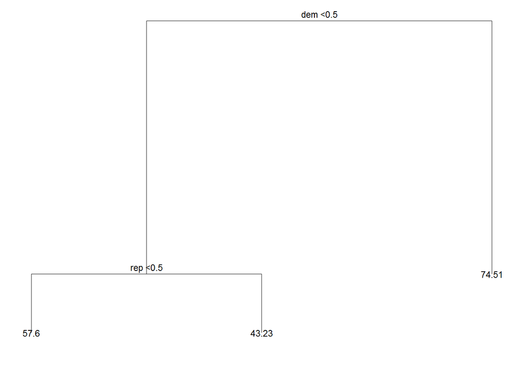

```r
# estimate model
biden_traintree <- tree(biden ~ female + age + educ + rep + dem, data = biden_train)

tree_data <- dendro_data(biden_traintree)
ptree <- ggplot(segment(tree_data)) +
  geom_segment(aes(x = x, y = y, xend = xend, yend = yend),
               alpha = 0.5) +
  geom_text(data = label(tree_data),
            aes(x = x, y = y, label = label_full), vjust = -0.5, size = 3) +
  geom_text(data = leaf_label(tree_data),
            aes(x = x, y = y, label = label), vjust = 0.5, size = 3) +
  theme_dendro()

ptree
```

```r
# Create function mse to calculate the mean squared error
mse <- function(model, data) {
  x <- modelr:::residuals(model, data)
  mean(x ^ 2, na.rm = TRUE)
}
```

```r
# set the random seed
set.seed(1234)

# generate 10-fold CV trees
biden_cv <- crossv_kfold(biden, k = 10) %>%
  mutate(tree = map(train, ~ tree(biden ~ female + age + educ + rep + dem, data = .)))

# Calculate the test MSE using the 10-fold cross validation approach
biden_cv10_models <- map(biden_cv$train, ~ tree(biden ~ age + female + educ + dem + rep, data = .))
biden_cv10_mse <- map2_dbl(biden_cv10_models, biden_cv$test, mse)
biden_mse <- mean(biden_cv10_mse)

biden_mse
```

```
## [1] 402.0678
```

3. Now fit another tree to the training data with the specified control options.

First, we find the optimal complexity of the tree by determing the optimal number of terminal nodes. We use 10-fold cross validation to get our test MSE for each prune attempt. Our graph of the test_mse as a function of the number of terminal nodes shows us that the test MSE is minimized at 3, so let’s chose 3 terminal nodes for our final tree model.

The final tree is plotted below, with 3 terminal nodes and the specified control options. As is quickly apparent, this tree is the same as that found using the default values for the tree function. The test MSE calculated using 10-fold cross validation is the same as found in question 2: 402.0678. In this case, pruning the tree has not done anything to improve the test MSE of the fitted tree.

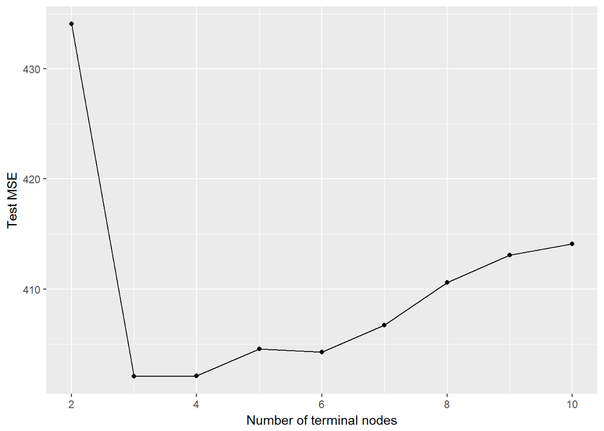

```r
# set random seed
set.seed(1234)

# generate 10-fold CV trees
biden_cv2 <- crossv_kfold(biden, k = 10) %>%
  mutate(tree = map(train, ~ tree(biden ~ female + age + educ + rep + dem, data = .,
                                  control = tree.control(nobs = nrow(biden),
                              mindev = 0))))


# calculate each possible prune result for each fold
biden_cv2 <- expand.grid(biden_cv2$.id, 2:10) %>%
  as_tibble() %>%
  mutate(Var2 = as.numeric(Var2)) %>%
  rename(.id = Var1,
         k = Var2) %>%
  left_join(biden_cv2) %>%
  mutate(prune = map2(tree, k, ~ prune.tree(.x, best = .y)),
         mse = map2_dbl(prune, test, mse))
biden2_mse <- biden_cv2 %>%
  select(k, mse) %>%
  group_by(k) %>%
  summarize(test_mse = mean(mse),
            sd = sd(mse, na.rm = TRUE))

biden2_mse %>%
  ggplot(aes(k, test_mse)) +
  geom_point() +
  geom_line() +
  labs(x = "Number of terminal nodes",
       y = "Test MSE")
```

```r
biden2_mse
```

```
## # A tibble: 9 × 3
##       k test_mse       sd
##   <dbl>    <dbl>    <dbl>
## 1     2 434.0820 28.84388
## 2     3 402.0678 38.45032
## 3     4 402.1037 39.40693
## 4     5 404.5545 39.62596
## 5     6 404.2501 38.91731
## 6     7 406.7001 41.27045
## 7     8 410.5904 40.44648
## 8     9 413.0927 38.31449
## 9    10 414.0869 37.30918
```

Generate the optimal tree with terminal nodes = 3

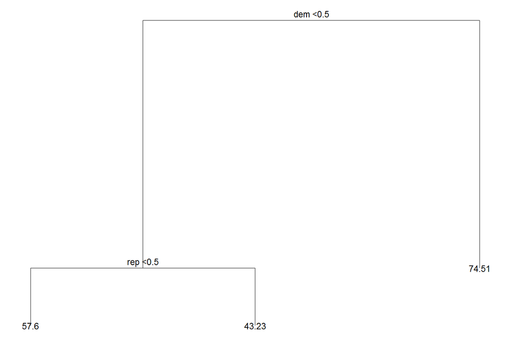

```r
# generate tree model
biden_traintree2 <- tree(biden ~ female + age + educ + rep + dem, data = biden_split$train,
                        control = tree.control(nobs = nrow(biden_train),
                              mindev = 0))

# prune the model using terminal nodes = 3
mod_biden_tree <- prune.tree(biden_traintree2, best = 3)

# plot the tree
tree_data2 <- dendro_data(mod_biden_tree)
ptree2 <- ggplot(segment(tree_data2)) +
  geom_segment(aes(x = x, y = y, xend = xend, yend = yend),
               alpha = 0.5) +
  geom_text(data = label(tree_data),
            aes(x = x, y = y, label = label_full), vjust = -0.5, size = 3) +
  geom_text(data = leaf_label(tree_data),
            aes(x = x, y = y, label = label), vjust = 0.5, size = 3) +
  theme_dendro()

ptree2
```

4. Use the bagging approach to analyze this data. What test MSE do you obtain? Obtain variable importance measures and interpret the results.

The test MSE obtained by the bagging method is 492.7417. The test MSE, in this case, is measured using OOB predictions, which are a sample (1/3, in typically) of observations held separate during the construction of each tree in the bagging/randomForest approach. This is larger than the test MSE obtained using the decision tree approach and indicates that the predictive accuracy of this bagging method may not be as good as the that for the standard decision tree.

Since this is a regression tree, the variable importance is a measure of how large a minimization in the RSS occurs due to the splits ocurring over a given predictor. We can look at either the plot or the table showing these values, below, and find that age has the most impact in predicting outcome, then democrat, education, republican, and finally gender. The bagging method is known to result in the collinearity of trees, resulting from the fact that the predictors resulting in the largest initial reduction in will almost always be used to build the first few splits of a tree. Since the collinearity will also affect the calculation of RSS reduction size, the variable importance ranking should be considered with a grain of salt - these variables are important per the model, but the model itself may not be the best fit for the data.

Implement the bagging approach:

```r
set.seed(1234)

# perform bagging on the training set
biden_bag <- randomForest(biden ~ ., data = biden,
                             mtry = 5, ntree = 500)

# print results
print(biden_bag)
```

```
##
## Call:
##  randomForest(formula = biden ~ ., data = biden, mtry = 5, ntree = 500)
##                Type of random forest: regression
##                      Number of trees: 500
## No. of variables tried at each split: 5
##
##           Mean of squared residuals: 492.7417
##                     % Var explained: 10.44
```

```r
# Get variable importance measures
importance(biden_bag)
```

```
##        IncNodePurity
## female      34948.36
## age        308290.97
## educ       145407.18
## dem        206080.91
## rep         64656.00
```

Plot of the variables in succeeding importance:

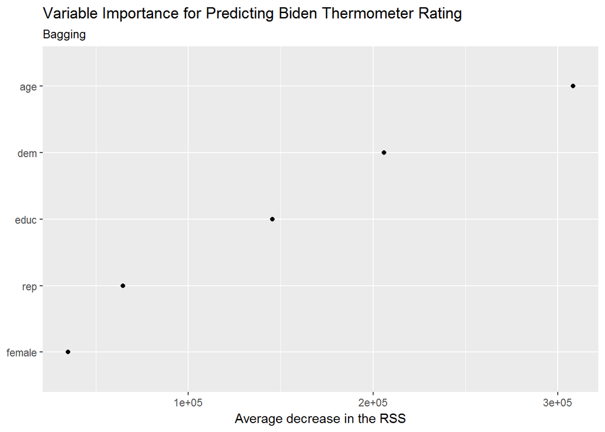

```r
data_frame(var = rownames(importance(biden_bag)),
           MeanDecreaseRSS = importance(biden_bag)[,1]) %>%
  mutate(var = fct_reorder(var, MeanDecreaseRSS, fun = median)) %>%
  ggplot(aes(var, MeanDecreaseRSS)) +
  geom_point() +
  coord_flip() +
  labs(title = "Variable Importance for Predicting Biden Thermometer Rating",
       subtitle = "Bagging",
       x = NULL,
       y = "Average decrease in the RSS")
```

5. Use the random forest approach to analyze this data. What test MSE do you obtain? Obtain variable importance measures and interpret the results. Describe the effect of m, the number of variables considered at each split, on the error rate obtained.

We can see that the variable importance measures produce a different ranking of importance through the randomForest approach. This is unsurprising, since the randomForest approach decreases collinearity of trees by only permitting a subset of predictors to be used to split the tree in each step, introducing more diversity into the types of trees constrcuted. With the randomForest approach, the predictor democrat now ranks highest in reducing RSS, then predictor republican, age, education, and finally gender. Interestintly, in both the bagging and randomForest approach, gender ranks the lowest in importance for both approaches.

Implement the randomForest approach:

```r
set.seed(1234)

# perform bagging on the training set
biden_rf <- randomForest(biden ~ ., data = biden, ntree = 500)

# print results
print(biden_rf)
```

```
##
## Call:
##  randomForest(formula = biden ~ ., data = biden, ntree = 500)
##                Type of random forest: regression
##                      Number of trees: 500
## No. of variables tried at each split: 1
##
##           Mean of squared residuals: 407.013
##                     % Var explained: 26.02
```

```r
# Get variable importance measures
importance(biden_rf)
```

```
##        IncNodePurity
## female      10314.43
## age         18711.96
## educ        14341.93
## dem        101400.12
## rep         90923.42
```

Plot of the variables in succeeding importance:

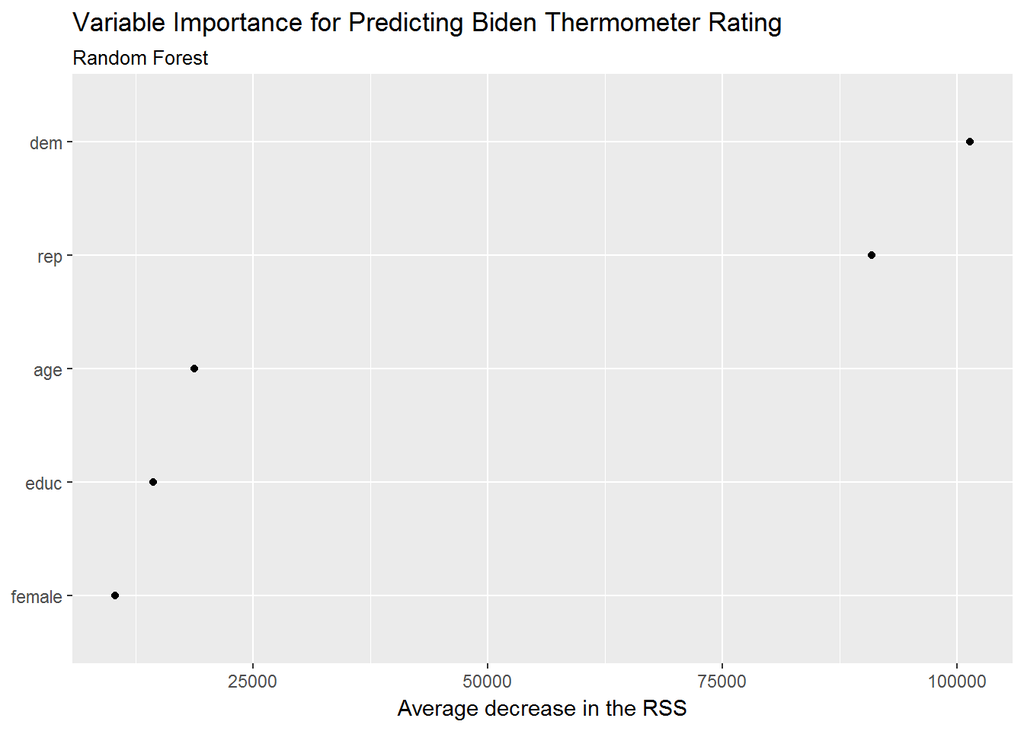

```r
data_frame(var = rownames(importance(biden_rf)),
           MeanDecreaseRSS = importance(biden_rf)[,1]) %>%
  mutate(var = fct_reorder(var, MeanDecreaseRSS, fun = median)) %>%
  ggplot(aes(var, MeanDecreaseRSS)) +
  geom_point() +
  coord_flip() +
  labs(title = "Variable Importance for Predicting Biden Thermometer Rating",
       subtitle = "Random Forest",
       x = NULL,
       y = "Average decrease in the RSS")
```

6. Use the boosting approach to analyze the data. What test MSE do you obtain? How does the value of the shrinkage parameter ?? influence the test MSE?

To illustrate the effect of the shrinkage parameter, the test MSE was again minimized for the optimal number of trees based on shrinkage parameters set at 0.001, 0.01, and 0.1. The shrinkage parameter controls how quickly the model “learns,” so as we see in the test MSEs reported below, as the shrinkage parameter grows, a small test MSE is achieved quickly. The downside of using a larger (more quickly learning) shrinkage parameter is the tradeoff in final model performance: because the model learns quickly, an observed optimized test MSE for our sample may simply be due to chance fit of the test data, and not representative of the approach’s performance over the total population.

```r
# set random seed
set.seed(1234)

# run multiple models
biden_boost_models <- list("boosting_depth1" = gbm(biden ~ .,
                                               data = biden_split$train,
                                               n.trees = 10000, interaction.depth = 1),
                       "boosting_depth2" = gbm(biden ~ .,
                                               data = biden_split$train,
                                               n.trees = 10000, interaction.depth = 2),
                       "boosting_depth4" = gbm(biden ~ .,
                                               data = biden_split$train,
                                               n.trees = 10000, interaction.depth = 4))
```

```
## Distribution not specified, assuming gaussian ...
## Distribution not specified, assuming gaussian ...
## Distribution not specified, assuming gaussian ...
```

```r
data_frame(depth = c(1, 2, 4),
           model = biden_boost_models[c("boosting_depth1", "boosting_depth2", "boosting_depth4")],
           optimal = map_dbl(model, gbm.perf, plot.it = FALSE))
```

```
## Using OOB method...
```

```
## Using OOB method...
```

```
## Using OOB method...
```

[output not shown]

```r
# set random seed
set.seed(1234)

# run multiple models with optimized parameters
biden_boost_opt <- list("boosting_depth1" = gbm(biden ~ .,
                                               data = biden_split$train,
                                               n.trees = 3353, interaction.depth = 1),
                       "boosting_depth2" = gbm(biden ~ .,
                                               data = biden_split$train,
                                               n.trees = 2597, interaction.depth = 2),
                       "boosting_depth4" = gbm(biden ~ .,
                                               data = biden_split$train,
                                               n.trees = 2119, interaction.depth = 4))
```

```
## Distribution not specified, assuming gaussian ...
## Distribution not specified, assuming gaussian ...
## Distribution not specified, assuming gaussian ...
```

```r
# set the random seed
set.seed(1234)

# get predictions on the test data
boost1_pred <- predict(biden_boost_models$boosting_depth1,
                       newdata = as_tibble(biden_split$test),
                       n.trees = 3353)
boost2_pred <- predict(biden_boost_models$boosting_depth2,
                       newdata = as_tibble(biden_split$test),
                       n.trees = 2597)
boost4_pred <- predict(biden_boost_models$boosting_depth4,
                       newdata = as_tibble(biden_split$test),
                       n.trees = 2119)

# print the MSE for the test set
boost1_mse <- mean((boost1_pred - biden_test$biden)^2)
boost1_mse
```

```
## [1] 405.2066
```

```r
boost2_mse <- mean((boost2_pred - biden_test$biden)^2)
boost2_mse
```

```
## [1] 402.9719
```

```r
boost4_mse <- mean((boost4_pred - biden_test$biden)^2)
boost4_mse
```

```
## [1] 404.6801
```

```r
# set the random seed
set.seed(1234)

# run multiple models with optimized parameters
biden_boost_shrink <- list("boosting_shrink1" = gbm(biden ~ .,
                                               data = biden_split$train,
                                               n.trees = 3353, interaction.depth = 2, shrinkage = 0.001),
                       "boosting_shrink2" = gbm(biden ~ .,
                                               data = biden_split$train,
                                               n.trees = 2597, interaction.depth = 2, shrinkage = 0.01),
                       "boosting_shrink3" = gbm(biden ~ .,
                                               data = biden_split$train,
                                               n.trees = 2119, interaction.depth = 2, shrinkage = 0.1))
```

```
## Distribution not specified, assuming gaussian ...
## Distribution not specified, assuming gaussian ...
## Distribution not specified, assuming gaussian ...
```

```r
# get optimal number of trees
data_frame(shrinkage = c(0.001, 0.01, 0.1),
           model = biden_boost_shrink[c("boosting_shrink1", "boosting_shrink2", "boosting_shrink3")],
           optimal = map_dbl(model, gbm.perf, plot.it = FALSE))
```

```
## Using OOB method...
```

```
## Using OOB method...
```

```
## Using OOB method...
```

```
## # A tibble: 3 × 3
##   shrinkage     model optimal
##       <dbl>    <list>   <dbl>
## 1     0.001 <S3: gbm>    2653
## 2     0.010 <S3: gbm>     252
## 3     0.100 <S3: gbm>      45
```

```r
# set the random seed
set.seed(1234)

# get predictions on the test data
shrink1_pred <- predict(biden_boost_shrink$boosting_shrink1,
                       newdata = as_tibble(biden_split$test),
                       n.trees = 2653)
shrink2_pred <- predict(biden_boost_shrink$boosting_shrink2,
                       newdata = as_tibble(biden_split$test),
                       n.trees = 252)
shrink3_pred <- predict(biden_boost_shrink$boosting_shrink3,
                       newdata = as_tibble(biden_split$test),
                       n.trees = 45)

# print the MSE for the test set
shrink1_mse <- mean((shrink1_pred - biden_test$biden)^2)
shrink1_mse
```

```
## [1] 402.9551
```

```r
shrink2_mse <- mean((shrink2_pred - biden_test$biden)^2)
shrink2_mse
```

```
## [1] 402.9072
```

```r
shrink3_mse <- mean((shrink3_pred - biden_test$biden)^2)
shrink3_mse
```

```
## [1] 400.8294
```

Part 2: Modeling Voter Turnout

Import data:

```r
#voter_data <- read_csv("data/mental_health.csv")

(voter <- read_csv("data/mental_health.csv") %>%
  mutate_each(funs(as.factor(.)), vote96, black, female, married) %>%
  na.omit)
```

```
## # A tibble: 1,165 × 8
##    vote96 mhealth_sum   age  educ  black female married   inc10
##    <fctr>       <dbl> <dbl> <dbl> <fctr> <fctr>  <fctr>   <dbl>
## 1       1           0    60    12      0      0       0  4.8149
## 2       1           1    36    12      0      0       1  8.8273
## 3       0           7    21    13      0      0       0  1.7387
## 4       0           6    29    13      0      0       0 10.6998
## 5       1           1    41    15      1      1       1  8.8273
## 6       1           2    48    20      0      0       1  8.8273
## 7       0           9    20    12      0      1       0  7.2223
## 8       0          12    27    11      0      1       0  1.2037
## 9       1           2    28    16      0      0       1  7.2223
## 10      1           0    72    14      0      0       1  4.0124
## # ... with 1,155 more rows
```

```r
#voter <- voter_data %>%
#    na.omit
```

1. Use cross-validation techniques and standard measures of model fit (e.g. test error rate, PRE, ROC curves/AUC) to compare and evaluate at least five tree-based models of voter turnout. Select the best model and interpret the results using whatever methods you see fit (graphs, tables, model fit statistics, predictions for hypothetical observations, etc.)

First, the data was split into 70% training, 30% testing sets. Five different tree-based methods were examined.

The first two tree-based methods tried were standard classification trees using all 7 predictors, one with and the other without pruning. The pruning did not improve the AUC, PRE or test classification error rate, despite attempts to optimize the terminal node number on the training set (6 terminal nodes, compared to the 7 terminal nodes obtained using default parameters). Regardless, these methods both returned a PRE of ~9.4%, indicating a 9.4% improvement over useless classifier.

```r
# set the seed
set.seed(1234)


# split the data into training and test set
voter_split <- resample_partition(voter, c(test = .3, train = .7))
```

Standard decision tree without pruning, all 7 predictors

```r
# Create decision tree
voter_tree1 <- tree(vote96 ~ ., data = as_tibble(voter_split$train))
voter_tree1
```

```
## node), split, n, deviance, yval, (yprob)
##       * denotes terminal node
##
##  1) root 816 1023.000 1 ( 0.31985 0.68015 )
##    2) mhealth_sum < 4.5 648  735.300 1 ( 0.25463 0.74537 )
##      4) age < 44.5 346  450.300 1 ( 0.35549 0.64451 )
##        8) educ < 14.5 214  296.000 1 ( 0.47196 0.52804 ) *
##        9) educ > 14.5 132  118.900 1 ( 0.16667 0.83333 )
##         18) mhealth_sum < 0.5 39    9.301 1 ( 0.02564 0.97436 ) *
##         19) mhealth_sum > 0.5 93   99.350 1 ( 0.22581 0.77419 ) *
##      5) age > 44.5 302  243.600 1 ( 0.13907 0.86093 )
##       10) educ < 15.5 217  207.400 1 ( 0.18433 0.81567 ) *
##       11) educ > 15.5 85   18.950 1 ( 0.02353 0.97647 ) *
##    3) mhealth_sum > 4.5 168  229.500 0 ( 0.57143 0.42857 )
##      6) age < 30.5 45   45.040 0 ( 0.80000 0.20000 ) *
##      7) age > 30.5 123  170.400 1 ( 0.48780 0.51220 ) *
```

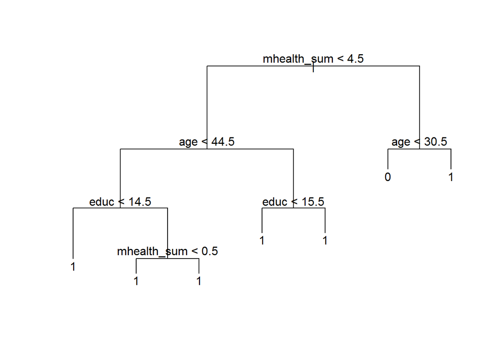

```r
plot(voter_tree1)
text(voter_tree1, pretty = 0)
```

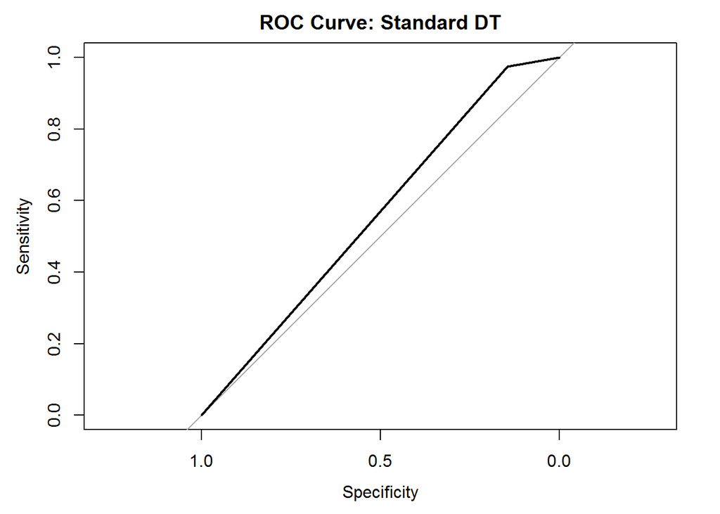

```r
tree_fitted1 <- predict(voter_tree1, as_tibble(voter_split$test), type = 'class')
tree_err1 <- mean(as_tibble(voter_split$test)$vote96 != tree_fitted1)

roc_tree1 <- roc(as.numeric(as_tibble(voter_split$test)$vote96), as.numeric(tree_fitted1))
plot(roc_tree1, main="ROC Curve: Standard DT")
```

```r
auc(roc_tree1)
```

```
## Area under the curve: 0.5597
```

```r
tree_err1
```

```
## [1] 0.3037249
```

```r
voter_tree_testerr1 <- tree_errate(voter_tree1, voter_split$test)
voter_tree_testerr1
```

```
## [1] 0.3037249
```

```r
real <- as.numeric(as_tibble(voter_split$test)$vote96)
E1 <- mean(as.numeric(real != median(real)))
E2 <- voter_tree_testerr1

PRE <- (E1 - E2) / E1
PRE
```

```
## [1] 0.09401709
```

Standard tree with pruning (optimize number of nodes), all 7 predictors

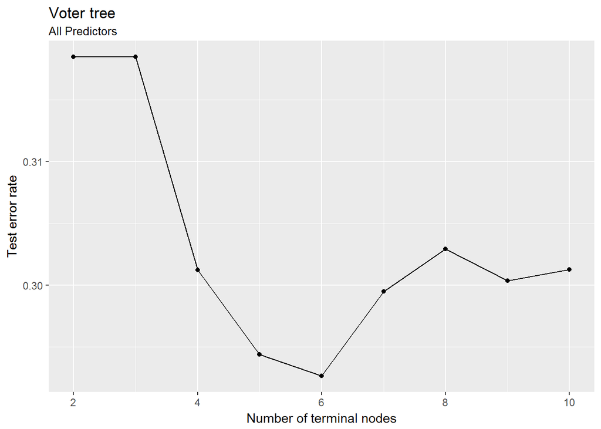

```r
# set random seed
set.seed(1234)

# generate 10-fold CV trees
voter_cv <- voter %>%
  na.omit() %>%
  crossv_kfold(k = 10) %>%
  mutate(tree = map(train, ~ tree(vote96 ~ ., data = .,
     control = tree.control(nobs = nrow(voter),
                            mindev = .001))))

# calculate each possible prune result for each fold
voter_cv <- expand.grid(voter_cv$.id,
                          seq(from = 2, to = 10)) %>%
  as_tibble() %>%
  mutate(Var2 = as.numeric(Var2)) %>%
  rename(.id = Var1,
         k = Var2) %>%
  left_join(voter_cv) %>%
  mutate(prune = map2(tree, k, ~ prune.misclass(.x, best = .y)),
         mse = map2_dbl(prune, test, tree_errate))
# plot the optimal number of terminal nodes
voter_cv %>%
  group_by(k) %>%
  summarize(test_mse = mean(mse),
            sd = sd(mse, na.rm = TRUE)) %>%
  ggplot(aes(k, test_mse)) +
  geom_point() +
  geom_line() +
  labs(title = "Voter tree",
       subtitle = "All Predictors",
       x = "Number of terminal nodes",
       y = "Test error rate")
```

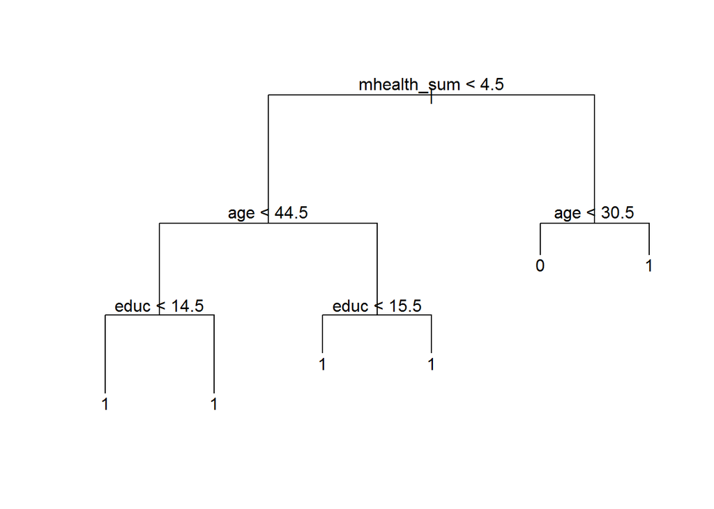

```r
# generate tree model with optimal nodes
voter_ptree <- tree(vote96 ~., data = voter_split$train)

# prune the model using terminal nodes = 3
voter_tree2 <- prune.tree(voter_ptree, best = 6)

plot(voter_tree2)
text(voter_tree2, pretty = 0)
```

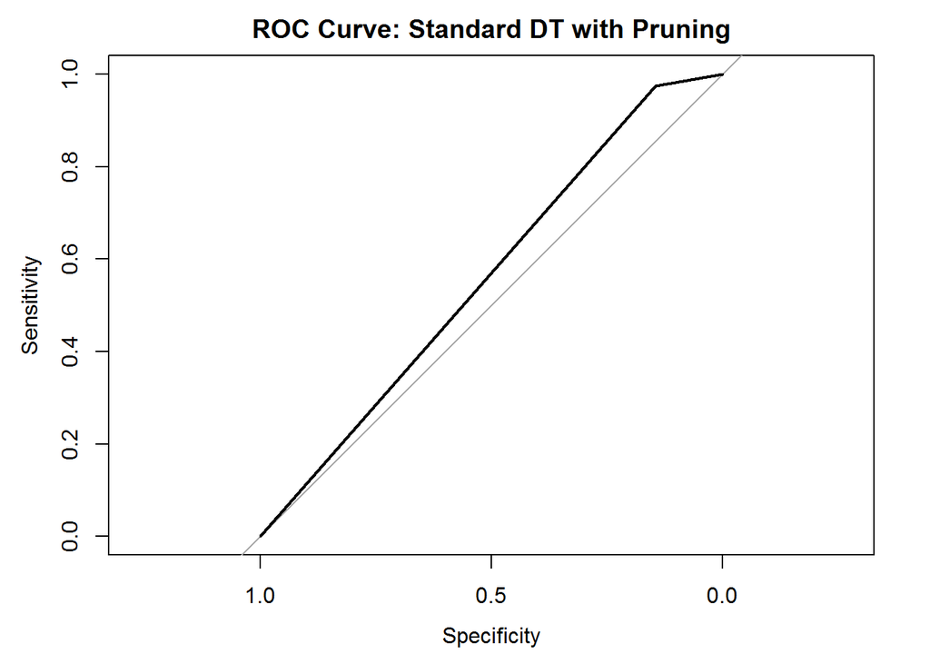

```r
tree_fitted2 <- predict(voter_tree2, as_tibble(voter_split$test), type = 'class')
tree_err2 <- mean(as_tibble(voter_split$test)$vote96 != tree_fitted2)

roc_tree2 <- roc(as.numeric(as_tibble(voter_split$test)$vote96), as.numeric(tree_fitted2))
plot(roc_tree2, main="ROC Curve: Standard DT with Pruning")
```

```r
auc(roc_tree2)
```

```
## Area under the curve: 0.5597
```

```r
tree_err2
```

```
## [1] 0.3037249
```

```r
voter_tree_testerr2 <- tree_errate(voter_tree2, voter_split$test)
voter_tree_testerr2
```

```
## [1] 0.3037249
```

```r
real <- as.numeric(as_tibble(voter_split$test)$vote96)
E1 <- mean(as.numeric(real != median(real)))
E2 <- voter_tree_testerr2

PRE <- (E1 - E2) / E1
PRE
```

```
## [1] 0.09401709
```

Standard decision tree with only mental health, race, and income as predictors

```r
# Create decision tree
voter_tree3 <- tree(vote96 ~ mhealth_sum + inc10 + black, data = as_tibble(voter_split$train))
voter_tree3
```

```
## node), split, n, deviance, yval, (yprob)
##       * denotes terminal node
##
## 1) root 816 1023.0 1 ( 0.3199 0.6801 )
##   2) mhealth_sum < 4.5 648  735.3 1 ( 0.2546 0.7454 )
##     4) inc10 < 5.3499 429  524.6 1 ( 0.3007 0.6993 ) *
##     5) inc10 > 5.3499 219  195.7 1 ( 0.1644 0.8356 ) *
##   3) mhealth_sum > 4.5 168  229.5 0 ( 0.5714 0.4286 ) *
```

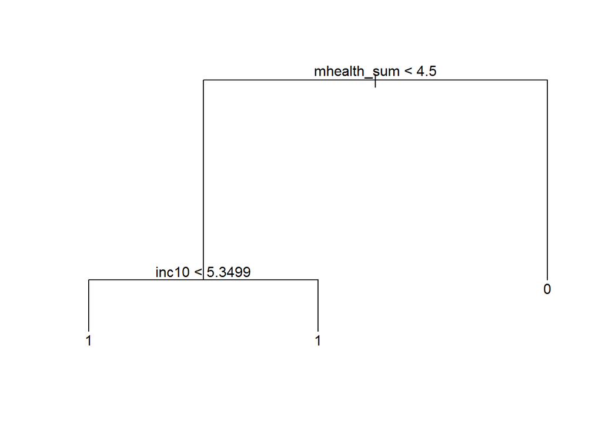

```r
plot(voter_tree3)
text(voter_tree3, pretty = 0)
```

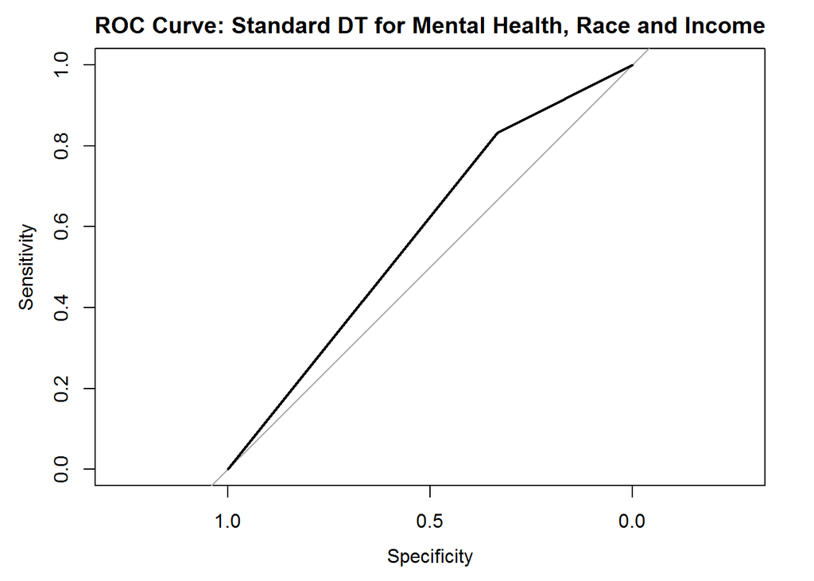

```r
tree_fitted3 <- predict(voter_tree3, as_tibble(voter_split$test), type = 'class')
tree_err3 <- mean(as_tibble(voter_split$test)$vote96 != tree_fitted3)

roc_tree3 <- roc(as.numeric(as_tibble(voter_split$test)$vote96), as.numeric(tree_fitted3))
plot(roc_tree3, main="ROC Curve: Standard DT for Mental Health, Race and Income")
```

```r
auc(roc_tree3)
```

```
## Area under the curve: 0.5826
```

```r
tree_err3
```

```
## [1] 0.3352436
```

```r
voter_tree_testerr3 <- tree_errate(voter_tree3, voter_split$test)
voter_tree_testerr3
```

```
## [1] 0.3352436
```

```r
real <- as.numeric(as_tibble(voter_split$test)$vote96)
E1 <- mean(as.numeric(real != median(real)))
E2 <- voter_tree_testerr3

PRE <- (E1 - E2) / E1
PRE
```

```
## [1] 0
```

Bagging Method

```r
# set the random seed
set.seed(1234)

voter_tree4 <- randomForest(vote96 ~ ., data = as_tibble(voter_split$train), mtry = 7)
voter_tree4
```

```
##
## Call:
##  randomForest(formula = vote96 ~ ., data = as_tibble(voter_split$train),      mtry = 7)
##                Type of random forest: classification
##                      Number of trees: 500
## No. of variables tried at each split: 7
##
##         OOB estimate of  error rate: 31.86%
## Confusion matrix:
##     0   1 class.error
## 0 116 145   0.5555556
## 1 115 440   0.2072072
```

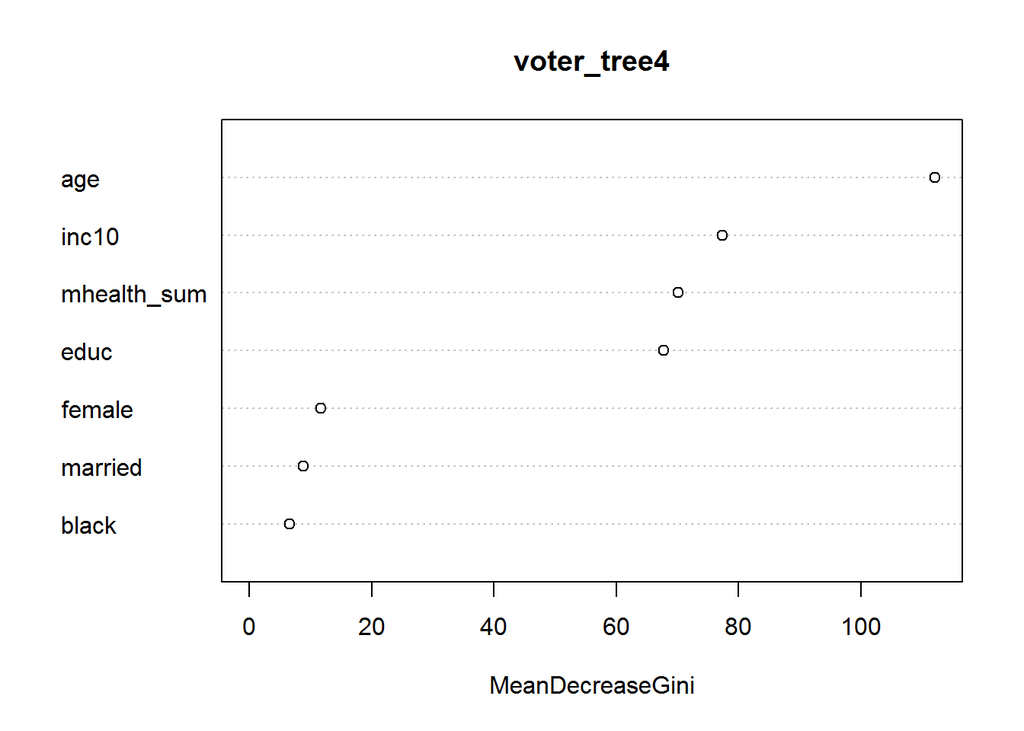

```r
varImpPlot(voter_tree4)
```

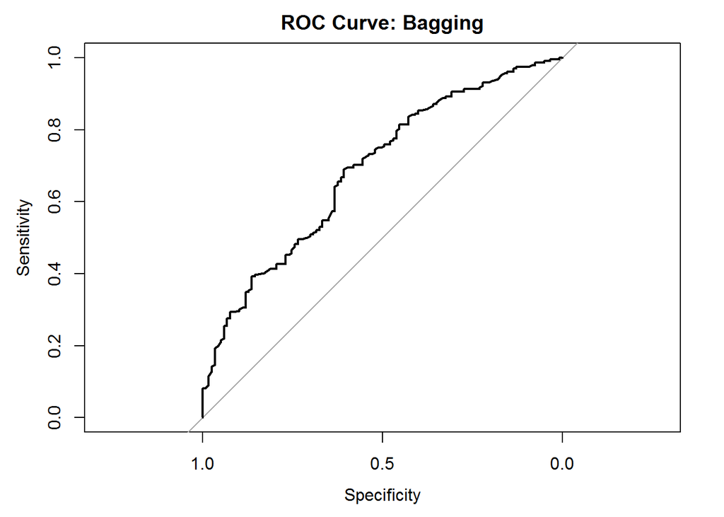

```r
fitted4 <- predict(voter_tree4, as_tibble(voter_split$test), type = "prob")[,2]
tree_err4 <- mean(as_tibble(voter_split$test)$vote96 != fitted4)

roc_tree4 <- roc(as_tibble(voter_split$test)$vote96, fitted4)
plot(roc_tree4, main="ROC Curve: Bagging")
```

```r
auc(roc_tree4)
```

```
## Area under the curve: 0.6882
```

```r
voter_tree_testerr4 <- tree_errate(voter_tree4, voter_split$test)
tree_err4
```

```
## [1] 0.9942693
```

```r
voter_tree_testerr4
```

```
## [1] 0.3151862
```

```r
real <- as.numeric(as_tibble(voter_split$test)$vote96)
E1 <- mean(as.numeric(real != median(real)))
E2 <- voter_tree_testerr4

PRE <- (E1 - E2) / E1
PRE
```

```
## [1] 0.05982906
```

Random Forest Method

```r
# set the random seed
set.seed(1234)

voter_tree5 <- randomForest(vote96 ~ ., data = as_tibble(voter_split$train))
voter_tree5
```

```
##
## Call:
##  randomForest(formula = vote96 ~ ., data = as_tibble(voter_split$train))
##                Type of random forest: classification
##                      Number of trees: 500
## No. of variables tried at each split: 2
##
##         OOB estimate of  error rate: 29.78%
## Confusion matrix:
##     0   1 class.error
## 0 105 156   0.5977011
## 1  87 468   0.1567568
```

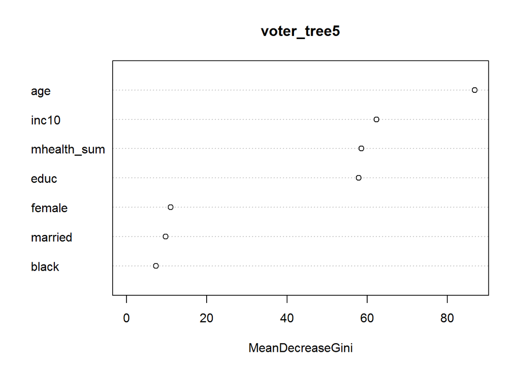

```r
varImpPlot(voter_tree5)
```

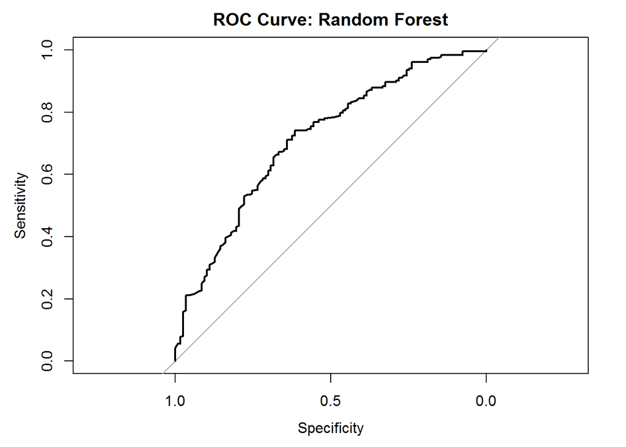

```r
fitted5 <- predict(voter_tree5, as_tibble(voter_split$test), type = "prob")[,2]
tree_err5 <- mean(as_tibble(voter_split$test)$vote96 != fitted5)

roc_tree5 <- roc(as_tibble(voter_split$test)$vote96, fitted5)
plot(roc_tree5, main="ROC Curve: Random Forest")
```

```r
auc(roc_tree5)
```

```
## Area under the curve: 0.7127
```

```r
voter_tree_testerr5 <- tree_errate(voter_tree5, voter_split$test)
tree_err5
```

```
## [1] 0.991404
```

```r
voter_tree_testerr5
```

```
## [1] 0.3008596
```

```r
real <- as.numeric(as_tibble(voter_split$test)$vote96)
E1 <- mean(as.numeric(real != median(real)))
E2 <- voter_tree_testerr5

PRE <- (E1 - E2) / E1
PRE
```

```
## [1] 0.1025641
```

Compare the 5 ROC curves

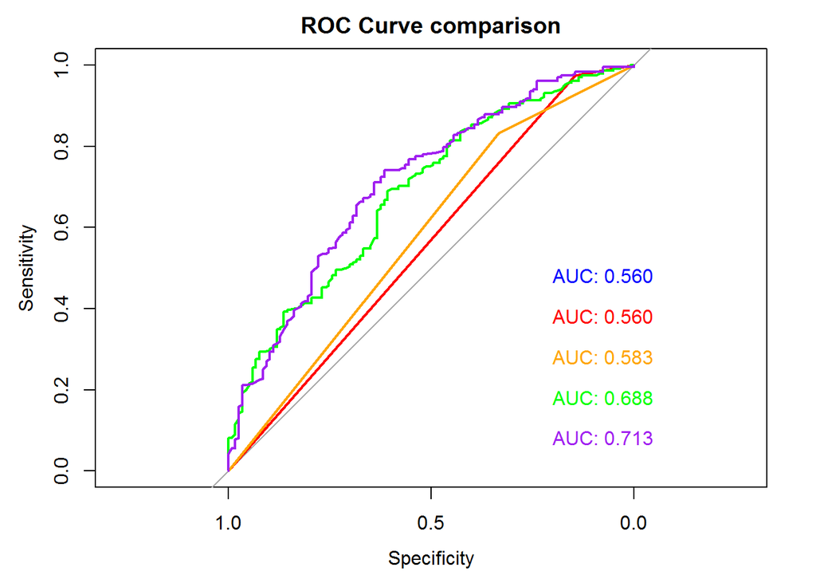

```r
plot(roc_tree1, print.auc = TRUE, col = "blue", print.auc.x = .2, main = "ROC Curve comparison")
plot(roc_tree2, print.auc = TRUE, col = "red", print.auc.x = .2, print.auc.y = .4, add = TRUE)
plot(roc_tree3, print.auc = TRUE, col = "orange", print.auc.x = .2, print.auc.y = .3, add = TRUE)
plot(roc_tree4, print.auc = TRUE, col = "green", print.auc.x = .2, print.auc.y = .2, add = TRUE)
plot(roc_tree5, print.auc = TRUE, col = "purple", print.auc.x = .2, print.auc.y = .1, add = TRUE)
```

2. Use cross-validation techniques and standard measures of model fit (e.g. test error rate, PRE, ROC curves/AUC) to compare and evaluate at least five SVM models of voter turnout. Select the best model and interpret the results using whatever methods you see fit (graphs, tables, model fit statistics, predictions for hypothetical observations, etc.)